# Modelling Process

```r
library(dplyr)
library(ggplot2)

# Modeling process packages
library(rsample)
library(caret)
# library(h2o)

# h2o set-up
# h2o.no_progress() # turn off h2o progress bars
# h2o.init() # launch h2o
```

```r
# ames housing data
ames <- AmesHousing::make_ames()
# ames_h2o <- as.h2o(ames)

DT::datatable(ames)
```

|  | MS_SubClass | MS_Zoning | Lot_Frontage | Lot_Area | Street | Alley | Lot_Shape | Land_Contour | Utilities | Lot_Config | Land_Slope | Neighborhood | Condition_1 | Condition_2 | Bldg_Type | House_Style | Overall_Qual | Overall_Cond | Year_Built | Year_Remod_Add | Roof_Style | Roof_Matl | Exterior_1st | Exterior_2nd | Mas_Vnr_Type | Mas_Vnr_Area | Exter_Qual | Exter_Cond | Foundation | … |
| --- | --- | --- | --- | --- | --- | --- | --- | --- | --- | --- | --- | --- | --- | --- | --- | --- | --- | --- | --- | --- | --- | --- | --- | --- | --- | --- | --- | --- | --- | --- |
| 1 | One_Story_1946_and_Newer_All_Styles | Residential_Low_Density | 141 | 31770 | Pave | No_Alley_Access | Slightly_Irregular | Lvl | AllPub | Corner | Gtl | North_Ames | Norm | Norm | OneFam | One_Story | Above_Average | Average | 1960 | 1960 | Hip | CompShg | BrkFace | Plywood | Stone | 112 | Typical | Typical | CBlock | … |
| 2 | One_Story_1946_and_Newer_All_Styles | Residential_High_Density | 80 | 11622 | Pave | No_Alley_Access | Regular | Lvl | AllPub | Inside | Gtl | North_Ames | Feedr | Norm | OneFam | One_Story | Average | Above_Average | 1961 | 1961 | Gable | CompShg | VinylSd | VinylSd | None | 0 | Typical | Typical | CBlock | … |
| 3 | One_Story_1946_and_Newer_All_Styles | Residential_Low_Density | 81 | 14267 | Pave | No_Alley_Access | Slightly_Irregular | Lvl | AllPub | Corner | Gtl | North_Ames | Norm | Norm | OneFam | One_Story | Above_Average | Above_Average | 1958 | 1958 | Hip | CompShg | Wd Sdng | Wd Sdng | BrkFace | 108 | Typical | Typical | CBlock | … |
| 4 | One_Story_1946_and_Newer_All_Styles | Residential_Low_Density | 93 | 11160 | Pave | No_Alley_Access | Regular | Lvl | AllPub | Corner | Gtl | North_Ames | Norm | Norm | OneFam | One_Story | Good | Average | 1968 | 1968 | Hip | CompShg | BrkFace | BrkFace | None | 0 | Good | Typical | CBlock | … |
| 5 | Two_Story_1946_and_Newer | Residential_Low_Density | 74 | 13830 | Pave | No_Alley_Access | Slightly_Irregular | Lvl | AllPub | Inside | Gtl | Gilbert | Norm | Norm | OneFam | Two_Story | Average | Average | 1997 | 1998 | Gable | CompShg | VinylSd | VinylSd | None | 0 | Typical | Typical | PConc | … |
| 6 | Two_Story_1946_and_Newer | Residential_Low_Density | 78 | 9978 | Pave | No_Alley_Access | Slightly_Irregular | Lvl | AllPub | Inside | Gtl | Gilbert | Norm | Norm | OneFam | Two_Story | Above_Average | Above_Average | 1998 | 1998 | Gable | CompShg | VinylSd | VinylSd | BrkFace | 20 | Typical | Typical | PConc | … |
| 7 | One_Story_PUD_1946_and_Newer | Residential_Low_Density | 41 | 4920 | Pave | No_Alley_Access | Regular | Lvl | AllPub | Inside | Gtl | Stone_Brook | Norm | Norm | TwnhsE | One_Story | Very_Good | Average | 2001 | 2001 | Gable | CompShg | CemntBd | CmentBd | None | 0 | Good | Typical | PConc | … |
| 8 | One_Story_PUD_1946_and_Newer | Residential_Low_Density | 43 | 5005 | Pave | No_Alley_Access | Slightly_Irregular | HLS | AllPub | Inside | Gtl | Stone_Brook | Norm | Norm | TwnhsE | One_Story | Very_Good | Average | 1992 | 1992 | Gable | CompShg | HdBoard | HdBoard | None | 0 | Good | Typical | PConc | … |
| 9 | One_Story_PUD_1946_and_Newer | Residential_Low_Density | 39 | 5389 | Pave | No_Alley_Access | Slightly_Irregular | Lvl | AllPub | Inside | Gtl | Stone_Brook | Norm | Norm | TwnhsE | One_Story | Very_Good | Average | 1995 | 1996 | Gable | CompShg | CemntBd | CmentBd | None | 0 | Good | Typical | PConc | … |
| 10 | Two_Story_1946_and_Newer | Residential_Low_Density | 60 | 7500 | Pave | No_Alley_Access | Regular | Lvl | AllPub | Inside | Gtl | Gilbert | Norm | Norm | OneFam | Two_Story | Good | Average | 1999 | 1999 | Gable | CompShg | VinylSd | VinylSd | None | 0 | Typical | Typical | PConc | … |

[output cut: 2920 more lines]

```r
class(ames)
```

```
## [1] "tbl_df"     "tbl"        "data.frame"
```

```r
# class(ames_h2o)

# job description data
churn <- modeldata::attrition %>%
  mutate(across(where(is.ordered), .fns = factor, ordered = FALSE))

DT::datatable(churn)
```

|  | Age | Attrition | BusinessTravel | DailyRate | Department | DistanceFromHome | Education | EducationField | EnvironmentSatisfaction | Gender | HourlyRate | JobInvolvement | JobLevel | JobRole | JobSatisfaction | MaritalStatus | MonthlyIncome | MonthlyRate | NumCompaniesWorked | OverTime | PercentSalaryHike | PerformanceRating | RelationshipSatisfaction | StockOptionLevel | TotalWorkingYears | TrainingTimesLastYear | WorkLifeBalance | YearsAtCompany | YearsInCurrentRole | … |
| --- | --- | --- | --- | --- | --- | --- | --- | --- | --- | --- | --- | --- | --- | --- | --- | --- | --- | --- | --- | --- | --- | --- | --- | --- | --- | --- | --- | --- | --- | --- |
| 1 | 41 | Yes | Travel_Rarely | 1102 | Sales | 1 | College | Life_Sciences | Medium | Female | 94 | High | 2 | Sales_Executive | Very_High | Single | 5993 | 19479 | 8 | Yes | 11 | Excellent | Low | 0 | 8 | 0 | Bad | 6 | 4 | … |
| 2 | 49 | No | Travel_Frequently | 279 | Research_Development | 8 | Below_College | Life_Sciences | High | Male | 61 | Medium | 2 | Research_Scientist | Medium | Married | 5130 | 24907 | 1 | No | 23 | Outstanding | Very_High | 1 | 10 | 3 | Better | 10 | 7 | … |
| 4 | 37 | Yes | Travel_Rarely | 1373 | Research_Development | 2 | College | Other | Very_High | Male | 92 | Medium | 1 | Laboratory_Technician | High | Single | 2090 | 2396 | 6 | Yes | 15 | Excellent | Medium | 0 | 7 | 3 | Better | 0 | 0 | … |
| 5 | 33 | No | Travel_Frequently | 1392 | Research_Development | 3 | Master | Life_Sciences | Very_High | Female | 56 | High | 1 | Research_Scientist | High | Married | 2909 | 23159 | 1 | Yes | 11 | Excellent | High | 0 | 8 | 3 | Better | 8 | 7 | … |
| 7 | 27 | No | Travel_Rarely | 591 | Research_Development | 2 | Below_College | Medical | Low | Male | 40 | High | 1 | Laboratory_Technician | Medium | Married | 3468 | 16632 | 9 | No | 12 | Excellent | Very_High | 1 | 6 | 3 | Better | 2 | 2 | … |
| 8 | 32 | No | Travel_Frequently | 1005 | Research_Development | 2 | College | Life_Sciences | Very_High | Male | 79 | High | 1 | Laboratory_Technician | Very_High | Single | 3068 | 11864 | 0 | No | 13 | Excellent | High | 0 | 8 | 2 | Good | 7 | 7 | … |
| 10 | 59 | No | Travel_Rarely | 1324 | Research_Development | 3 | Bachelor | Medical | High | Female | 81 | Very_High | 1 | Laboratory_Technician | Low | Married | 2670 | 9964 | 4 | Yes | 20 | Outstanding | Low | 3 | 12 | 3 | Good | 1 | 0 | … |
| 11 | 30 | No | Travel_Rarely | 1358 | Research_Development | 24 | Below_College | Life_Sciences | Very_High | Male | 67 | High | 1 | Laboratory_Technician | High | Divorced | 2693 | 13335 | 1 | No | 22 | Outstanding | Medium | 1 | 1 | 2 | Better | 1 | 0 | … |
| 12 | 38 | No | Travel_Frequently | 216 | Research_Development | 23 | Bachelor | Life_Sciences | Very_High | Male | 44 | Medium | 3 | Manufacturing_Director | High | Single | 9526 | 8787 | 0 | No | 21 | Outstanding | Medium | 0 | 10 | 2 | Better | 9 | 7 | … |
| 13 | 36 | No | Travel_Rarely | 1299 | Research_Development | 27 | Bachelor | Medical | High | Male | 94 | High | 2 | Healthcare_Representative | High | Married | 5237 | 16577 | 6 | No | 13 | Excellent | Medium | 2 | 17 | 3 | Good | 7 | 7 | … |

[output cut: 1460 more lines]

```r
# churn_h2o <- as.h2o(churn)
```

## Data spliting using Random Sampling

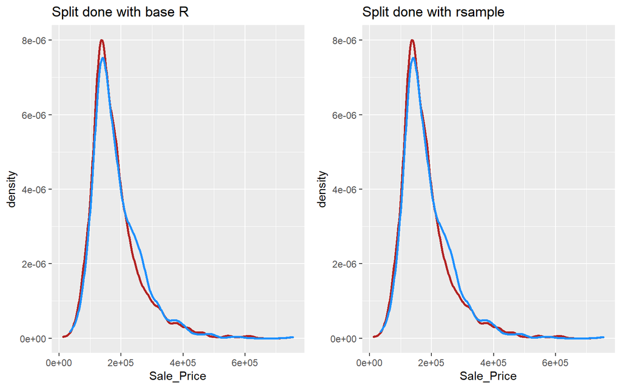

```r
# plot function for ames data

plot_dist <- function(train_data, test_data, title) {
  train_data %>%
  ggplot(aes(x = Sale_Price)) +
  geom_density(trim = TRUE, color = "firebrick", size = 1) +
  geom_density(data = test_data, trim = TRUE, color = "dodgerblue", size = 1) +
  ggtitle(title)
}


# using base-R
set.seed(123)

# In ames data, we are interested in Sales Price (Y)

idx1 <- sample(1:nrow(ames), round(nrow(ames) * 0.7))
train1 <- ames[idx1, ]
test1 <- ames[-idx1, ]

p1 <- plot_dist(train1, test1, "Split done with base R")

set.seed(123)
split_dt <- rsample::initial_split(ames, prop = 0.7)
train2 <- training(split_dt)
test2 <- testing(split_dt)

p2 <- plot_dist(train2, test2, "Split done with rsample")

gridExtra::grid.arrange(p1, p2, nrow = 1)
```

#### We have similar distribution of Sales Price in both train and test data set

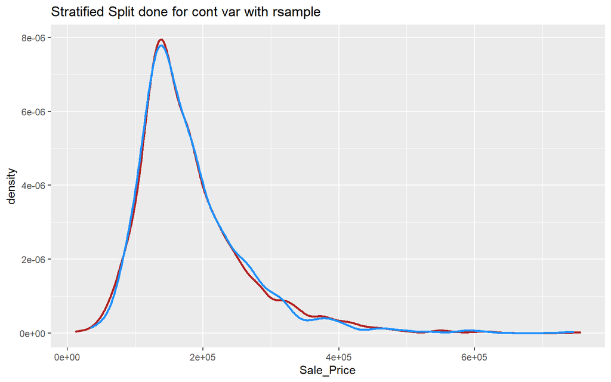

```r
set.seed(123)
split_strat_num <- initial_split(ames, prop = 0.7, strata = "Sale_Price")
train_strat_num <- training(split_strat_num)
test_strat_num <- testing(split_strat_num)

plot_dist(train_strat_num, test_strat_num,
          "Stratified Split done for cont var with rsample")
```

So we have a balanced representation of the response distn in both training and test set.

## Data splitting using Stratified sampling (for Categorical)

```r
prp <- . %>% table %>% prop.table

# original response distribution
prp(churn$Attrition)
```

```
## .
##        No       Yes
## 0.8387755 0.1612245
```

```r
# stratified sampling
set.seed(123)

split_strat <- initial_split(churn, prop = 0.7, strata = "Attrition")
train_strat <- training(split_strat)
test_strat <- testing(split_strat)

# Now response distribution in test and training set
prp(train_strat$Attrition)
```

```
## .
##        No       Yes
## 0.8394942 0.1605058
```

```r
prp(test_strat$Attrition)
```

```
## .
##        No       Yes
## 0.8371041 0.1628959
```

## Class Imbalances

When, in classification problem, class size differs significantly (e.g. 5% defaults, 95% non-defaults).

Two way to solve this issue of class-imbalance

- up-sampling
- down-sampling

In up-sampling, freqs of rares class increased by with replacment sampling with bootstrap, while in down-sampling, size of abundant class(es) is decrease to match up the frequency of least prevalent class.

A combination of both of these are = Synthetic Minority Over-sampling Technique (SMOTE) is often successfully used.

## Meta Engine vs Direct Engine

```r
# using direct engine
lm_lm <- lm(Sale_Price ~  ., data = ames)
glm_lm <- glm(Sale_Price ~  ., data = ames, family = "gaussian")

# using meta engine
invisible(capture.output(lm_caret <- caret::train(Sale_Price ~  ., data = ames,
                         method = "lm")))
```

Meta engines are like consistent interface to direct engines. Meta engines provide more consistent interface for input specification and output extraction, while less flexible than those direct engines.

## Resampling Method

We use resampling method to assess model performance during the training phase. We will use a validation approach where we divide training data into a training sets and validation set and two commonly used techniques are

- k-fold cross validation
- bootstrapping

### k-fold CV

```r
cv <- rsample::vfold_cv(mtcars, 10)

cv
```

```
## #  10-fold cross-validation
## # A tibble: 10 × 2
##    splits         id
##    <list>         <chr>
##  1 <split [28/4]> Fold01
##  2 <split [28/4]> Fold02
##  3 <split [29/3]> Fold03
##  4 <split [29/3]> Fold04
##  5 <split [29/3]> Fold05
##  6 <split [29/3]> Fold06
##  7 <split [29/3]> Fold07
##  8 <split [29/3]> Fold08
##  9 <split [29/3]> Fold09
## 10 <split [29/3]> Fold10
```

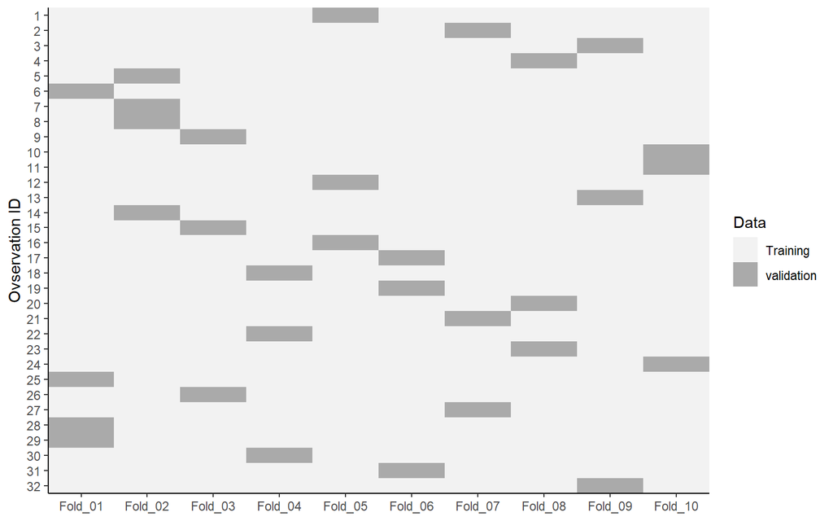

```r
cv$splits %>%
  purrr::map2_dfr(seq_along(cv$splits), ~ mtcars %>%
            mutate(
              resample = paste0("Fold_", stringr::str_pad(.y, 2, pad = 0)),
              ID = row_number(),
              Data = ifelse(ID %in% .x$in_id, "Training", "validation")
            )
  ) %>%
  ggplot(aes(resample, ID, fill = Data)) +
  geom_tile() +
  scale_fill_manual(values = c("#f2f2f2", "#AAAAAA")) +
  scale_y_reverse("Ovservation ID", breaks = 1:nrow(mtcars)) +
  labs(x = NULL) +
  coord_cartesian(expand = FALSE) +
  theme_classic()
```

### Bootstrapping

In this method, we create some bootstrap samples with the same size as original training data. But each sample contains duplicated values. So the original obs not contained in a particular bootstrap-sample are considered as `Out-of-Bag (OOB)` obs. So when bootstraping, model can be built on seleteced samples and validated against the OOB samples.

```r
rsample::bootstraps(ames, times = 10)
```

```
## # Bootstrap sampling
## # A tibble: 10 × 2
##    splits              id
##    <list>              <chr>
##  1 <split [2930/1084]> Bootstrap01
##  2 <split [2930/1090]> Bootstrap02
##  3 <split [2930/1073]> Bootstrap03
##  4 <split [2930/1042]> Bootstrap04
##  5 <split [2930/1077]> Bootstrap05
##  6 <split [2930/1123]> Bootstrap06
##  7 <split [2930/1087]> Bootstrap07
##  8 <split [2930/1060]> Bootstrap08
##  9 <split [2930/1083]> Bootstrap09
## 10 <split [2930/1060]> Bootstrap10
```

### .632 and .632+ bootstrapping method

In 1983, Bradly Efron described the *.632 Estimate*, a further improvement to address the pessimistic bias of the bootstrap.

This bias in the classic bootstrap method (OOB method) originates from the fact that bootstrap sample contains approximately only 63.2% of the unique samples from the original training set.

*.632 method* attempts to address both the `pessimistic bias of the estimate` and `optimistic bias of the model overfit`. *.632+* method uses more involved formula for computing the weight instead of the fixed weight `w = 0.632`.

## Hyperparameter tuning

Hyperparameters are parameters of the machine learning algorithm that control the model complexity and therefore, control the bias-variance tradeoff.

For automated hyperparameter tuning we use *grid search*. And there are many method of grid search

- full cartesian grid search
- random grid search
- early stopping grid search
- adaptive resampling

## Measures from confusion matrix

- **Accuracy**: Overall how often the model is accurate?

$$Accuracy = \frac{TP + TN}{total}$$

- **Precision**: How accurately the classifier predicts the events?

$$Precision = \frac{TP}{TP + FP}$$

- **Sensitivity**: How accurately does the classifier classify actual events?

$$Sensitivity = \frac{TP}{TP + FN}$$

- **Specificity**: How accurately the classifier classify actual non-events?

$$Specificity = \frac{TN}{TN + FP}$$

- **ROC curve**: A plot of True positive rate vs False Positive rate.

## Putting the process together

```r
# ames housing data
ames <- AmesHousing::make_ames()

set.seed(123)

# stratified sampling with the rsample package
split <- initial_split(ames, prop = 0.7, strata = "Sale_Price")
ames_train <- training(split)
ames_test <- testing(split)
```

Now we are going to apply a k-nearest neighbor regressor to the ames data.

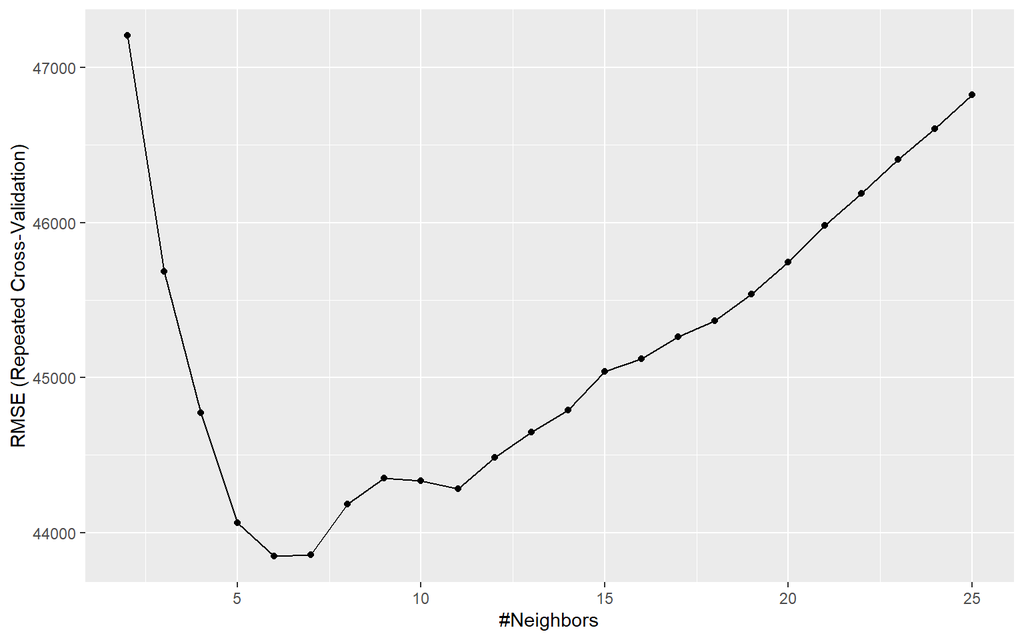

```r
# specify a resampling strategy
cv <- caret::trainControl(
  method = "repeatedcv",
  number = 10,
  repeats = 5
)

# create a grid of hyperparameter values (for grid-search)
hyper_grid <- expand.grid(k = seq(2, 25, by = 1))

# using xfun::cache_rds just to cache the time consuming
# modelling process, nothing important related to the model process itself

xfun::cache_rds({
  # Tune a knn model using the grid search
  knn_fit <- caret::train(
    Sale_Price ~ .,
    data = ames_train,
    method = "knn",
    trControl = cv,
    tuneGrid = hyper_grid,
    metric = "RMSE"
)

 knn_fit

 ggplot(knn_fit)

}, dir = here::here("R/cache", "cache_"), file = "knn.rds")
```